# Challenge Data Census US

Voici le resultat de la validation:

```
 Accuracy     Kappa
0.9515333 0.4697091
```

```
Confusion Matrix and Statistics

          Reference
Prediction -50000 +50000
    -50000  41184   1673
    +50000    478   1046

               Accuracy : 0.9515
                 95% CI : (0.9495, 0.9535)
    No Information Rate : 0.9387
    P-Value [Acc > NIR] : < 2.2e-16

                  Kappa : 0.4697

 Mcnemar's Test P-Value : < 2.2e-16

            Sensitivity : 0.9885
            Specificity : 0.3847
         Pos Pred Value : 0.9610
         Neg Pred Value : 0.6864
             Prevalence : 0.9387
         Detection Rate : 0.9280
   Detection Prevalence : 0.9657
      Balanced Accuracy : 0.6866

       'Positive' Class : -50000
```

Nous avons une faible erreur de validation et elle est équivalant à l’erreur d’apprentissage.

Le kappa est modéré avec un accord modéré de prédiction.

#### **Confusion Table**

Confusion Table NNET

|  | -50000 | +50000 |
| --- | --- | --- |
| -50000 | 41184 | 1673 |
| +50000 | 478 | 1046 |

La matrice de confusion suivante se lit alors comme suit :

#### **Resultat de la prédiction**

Resultats Neuronal Network

|  | Durée.Execution | Accuracy | Taux.Erreur | Recall | Precision |
| --- | --- | --- | --- | --- | --- |
| Neural Networks | 28.59946 mins | 0.9515333 | 0.0484667 | 0.9885267 | 0.9609632 |

Nous avons une très bonne accuracy pour la prédiction mais le temps d’excution est très long.

# Conclusion

Nous avons construit plusieurs modèles de classification pour prédire si un citoyen américain gagne plus ou moins de 50 000 $ par an. Nous avons utilisé le Stochastic Gradient Boosting ,la forêt aléatoire utilisant le bagging, les machines à vecteurs de support linéaire et à noyau, les arbres de décisions, les naives Bayes, kNN et Reseau de neurones. Dans le tableau ci-dessous, nous résumons l’accuracy, le taux d’erreur, le recall, la precision et le temps d’execution pour tous les modèles .

Le modèle le plus précis est le modèle **Stochastic Gradient Boosting**. En revanche, le modèle de **Naives Bayes** a la meilleure durée d’exécution avec seulement 5 min pour la modélisation avec les covariables mais il ne prédit pas les outcome “+50000”. Concernant le modèle **SVM radial**, il a un problème de sur-apprentissage d’où le faible score accuracy.

En termes de temps de calcul et précision, le meilleur modèle est **l’arbre de décision CART**.

En conclusion, après avoir pris en compte tous les indicateurs de performance, le modèle de l’arbre de décision semblent être le choix le plus approprié pour prédire la valeur outcome du dataset Census.

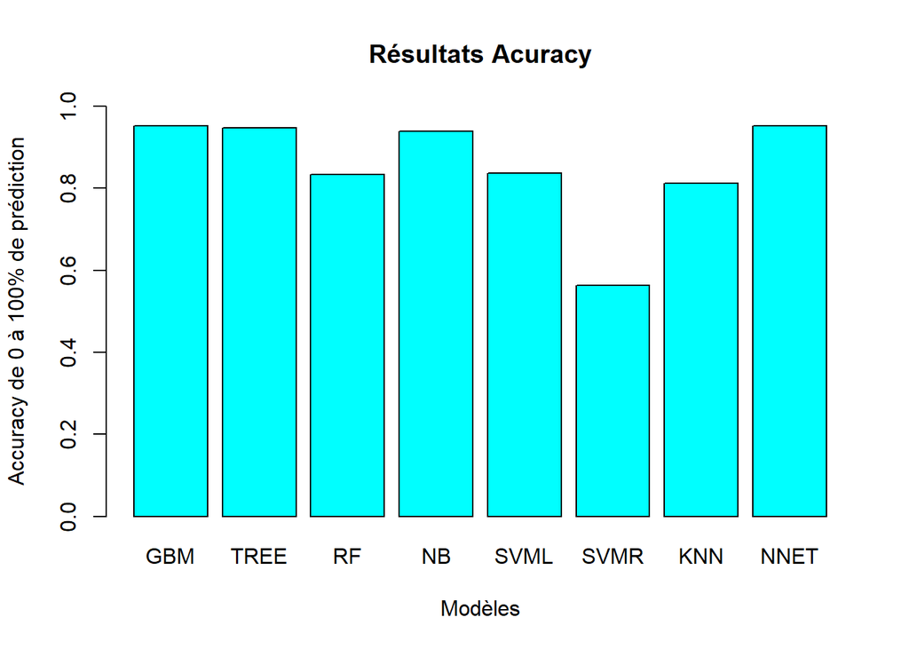

Resultats des 8 Algorithmes

|  | Accuracy | Taux.Erreur | Durée.Execution | Recall | Precision |
| --- | --- | --- | --- | --- | --- |
| Stochastic Gradient Boosting | 0.9520516 | 0.0479484 | 31.227520 mins | 0.9891988 | 0.9608767 |
| Classification Tree CART | 0.9468692 | 0.0531308 | 8.034623 mins | 0.9536682 | 0.9915751 |
| Random Forest | 0.8341407 | 0.1658593 | 14.986826 mins | 0.9924767 | 0.8296049 |
| Naives Bayes | 0.9387350 | 0.0612650 | 5.327326 mins | 1.0000000 | 0.9387350 |
| SVM linéaire | 0.8370474 | 0.1629526 | 20.343674 mins | 0.8326053 | 0.9926172 |
| SVM radial | 0.5627633 | 0.4372367 | 27.546775 mins | 0.5368681 | 0.9951061 |
| K nearest neighbors KNN | 0.8125099 | 0.1874901 | 13.292672 mins | 0.8067304 | 0.9920600 |
| Neural Networks | 0.9515333 | 0.0484667 | 28.599459 mins | 0.9885267 | 0.9609632 |

# Annexes

[output not shown]

[output cut: 337 more lines]

```
Call:
PCA(X = data_acp, quali.sup = 7, graph = FALSE)


Eigenvalues
                       Dim.1   Dim.2   Dim.3   Dim.4   Dim.5   Dim.6
Variance               1.866   1.123   1.001   0.910   0.850   0.251
% of var.             31.103  18.711  16.679  15.161  14.163   4.183
Cumulative % of var.  31.103  49.814  66.493  81.654  95.817 100.000

Individuals (the 10 first)
                                    Dist    Dim.1    ctr   cos2    Dim.2
284829                          |  2.100 |  1.825  0.001  0.755 | -0.257
21187                           |  1.287 | -1.267  0.000  0.970 | -0.028
64649                           |  1.287 | -1.267  0.000  0.970 | -0.028
12643                           |  1.287 | -1.267  0.000  0.970 | -0.028
21863                           |  1.287 | -1.267  0.000  0.970 | -0.028
169260                          |  2.056 |  0.973  0.000  0.224 | -0.343
258087                          |  1.287 | -1.267  0.000  0.970 | -0.028
164023                          |  5.086 |  0.251  0.000  0.002 | -0.843
18464                           |  2.188 |  1.906  0.001  0.759 |  0.222
148883                          |  1.493 |  1.267  0.000  0.719 | -0.205
                                   ctr   cos2    Dim.3    ctr   cos2
284829                           0.000  0.015 | -0.141  0.000  0.005 |
21187                            0.000  0.000 | -0.020  0.000  0.000 |
64649                            0.000  0.000 | -0.020  0.000  0.000 |
12643                            0.000  0.000 | -0.020  0.000  0.000 |
21863                            0.000  0.000 | -0.020  0.000  0.000 |
169260                           0.000  0.028 | -0.493  0.000  0.058 |
258087                           0.000  0.000 | -0.020  0.000  0.000 |
164023                           0.000  0.027 | -1.228  0.001  0.058 |
18464                            0.000  0.010 | -0.342  0.000  0.024 |
148883                           0.000  0.019 | -0.115  0.000  0.006 |

Variables
                                   Dim.1    ctr   cos2    Dim.2    ctr
wage_per_hour                   |  0.405  8.779  0.164 | -0.168  2.526
capital_gains                   |  0.154  1.279  0.024 |  0.713 45.267
capital_losses                  |  0.195  2.030  0.038 |  0.068  0.413
from_stocks                     |  0.048  0.123  0.002 |  0.759 51.299
num_persons_worked_for_employer |  0.902 43.609  0.814 | -0.065  0.382
weeks_worked_in_year            |  0.908 44.181  0.825 | -0.036  0.114
                                  cos2    Dim.3    ctr   cos2
wage_per_hour                    0.028 | -0.236  5.556  0.056 |
capital_gains                    0.508 | -0.282  7.968  0.080 |
capital_losses                   0.005 |  0.921 84.734  0.848 |
from_stocks                      0.576 |  0.127  1.605  0.016 |
num_persons_worked_for_employer  0.004 | -0.031  0.094  0.001 |
weeks_worked_in_year             0.001 | -0.020  0.042  0.000 |

Supplementary categories
                                      Dist      Dim.1     cos2   v.test
-50000                          |    0.124 |   -0.099    0.640 -125.844 |
+50000                          |    1.870 |    1.496    0.640  125.844 |
                                   Dim.2     cos2   v.test      Dim.3
-50000                            -0.070    0.321 -114.847 |   -0.018
+50000                             1.059    0.321  114.847 |    0.278
                                    cos2   v.test
-50000                             0.022  -31.958 |
+50000                             0.022   31.958 |
```